# Taller 1

Lissette Quebrada, Brayan Granada

2022-03-11

*1. Al comparar los caracteres morfométricos de una especie de langostinos de gran importancia económica en Argentina se observaron diferencias de tamaño entre macho y hembra. En la siguiente tabla se presentan los datos (Largo total mm) de las morfometrías de machos y hembras obtenidos en diferentes recolectas (Ruiz & Mendia, 2008).*

```r
hembras = c(183.2, 184.1, 183.1, 204.3, 176.5, 179.0, 188.3, 186.8, 202.2, 185.5, 190.0, 178.1, 193.2, 180.4, 184.3, 189.2, 189.1, 203.1, 166.8, 196.3, 193.3, 187.3, 185.8, 189.3, 195.5, 202.4, 210.8 )

length(hembras)
```

```
## [1] 27
```

```r
machos = c(140.9, 121.7, 173.8, 154.5, 109.2, 150.7, 203.3, 163, 137.7, 173.9, 177.4, 154.8, 177.5, 153.4, 138.7, 136.7, 165.3, 126.7, 118.9, 140, 192.7, 134.4, 175, 169.8, 153.9, 176.7, 150)
length(machos)
```

```
## [1] 27
```

*a. Haga un histograma con cinco clases y determine la distribución de los datos para cada sexo. Explique acerca de la distribución del tamaño para cada género.*

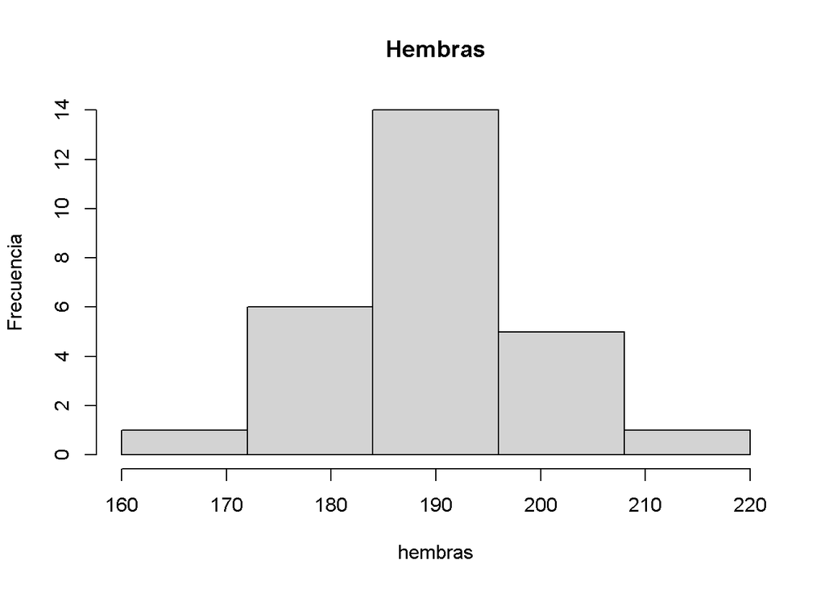

```r
hist(hembras, breaks = seq(160,220, by = 12), main = 'Hembras', ylab = 'Frecuencia')
```

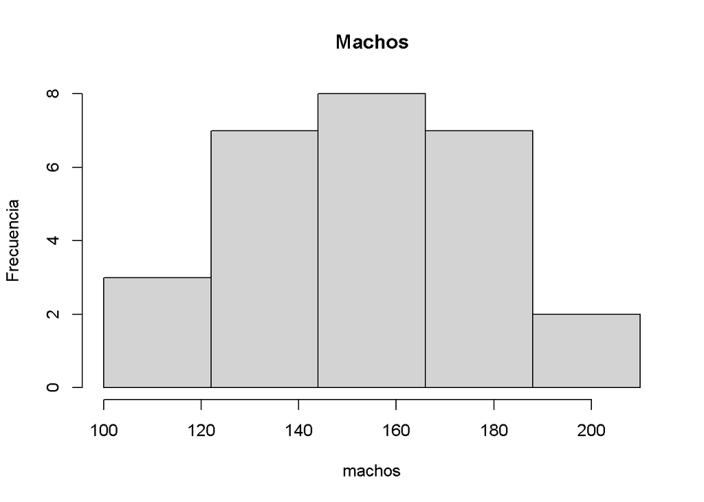

```r
hist(machos, breaks = seq(100,210, by =22), main = 'Machos', ylab = 'Frecuencia')
```

*Interpretación hembras: Ajuste adecuado. La curva tiene tendencia simetrica, su asimetria esta recargada sobre el lado izquierdo.* *Al graficar el histograma con los datos agrupados en las 5 clases no se evidencia datos atipicos pero al ver el comportamiento de los datos individualmente si existen valores muy pequeños o muy grandes respecto a la media*

*b. Hallar el promedio y la desviación estándar para cada sexo. ¿Qué puede concluir?*

```r
promedioh = mean(hembras)
promediom = mean(machos)

desviacionsh = sd(hembras)
desviacionsm = sd(machos)
```

*La mayoria de las hembras tienen un tamaño aproximado de 189.1815* *La mayoria de los hombres tienen un tamaño aproximado de 154.4667*

*La desviación estandar de los datos nos dice que los datos correspondientes a los machos estan mucho mas dispersos entre si, respecto a los datos de las hembras*

*d. Construya un Boxplot por sexo e interprételo.*

[figure not shown]

```r
boxplot(hembras, main = "Langostinos", xlab = "Tamaño (cm)", ylab = "Hembras",
        col = "pink", border = "red", horizontal = TRUE, notch = FALSE)
```

[figure not shown]

```r
boxplot(machos, main = "Langostinos", xlab = "Tamaño (cm)", ylab = "Machos",
        col = "purple", border = "black", horizontal = TRUE, notch = FALSE)
```

*En el diagrama se puede ver los datos atipicos de las hembras. En ambos casos los datos se concentran en la parte derecha (asimetria positiva)*

*2. En un restaurante de la ciudad se sabe que la probabilidad de que se reciba un billete de $50.000 falso es de 0.015. Si se sabe que en una semana se reciben pagos con 900 billetes de $50.000, halle la probabilidad de que:*

*a. A lo sumo 25 billetes sean falsos.*

```r
#x -> # billetes falsos
#n -> 900 billetes
#p -> 0.015

#p(x<=25)=p(x=1)+p(x=2)+p(x=3)+...+p(x=25)

cat("La probabilidad de recibir a lo sumo 25 billetes falsos es: ",pbinom(25,900,0.015))
```

```
## La probabilidad de recibir a lo sumo 25 billetes falsos es:  0.9985199
```

*b. La cantidad de billetes falsos esté entre 20 y 30.*

```r
cat("La probabilidad de recibir entre 20 y 30 billetes falsos es de: ",pbinom(30,900,0.015) - pbinom(20,900,0.015))
```

```
## La probabilidad de recibir entre 20 y 30 billetes falsos es de:  0.03395327
```

*c. Más de 10 sean falsos.*

```r
cat("La probabilidad de recibir mas de 10 billetes falsos es de: ",pbinom(10,900,0.015,F))
```

```
## La probabilidad de recibir mas de 10 billetes falsos es de:  0.7907816
```

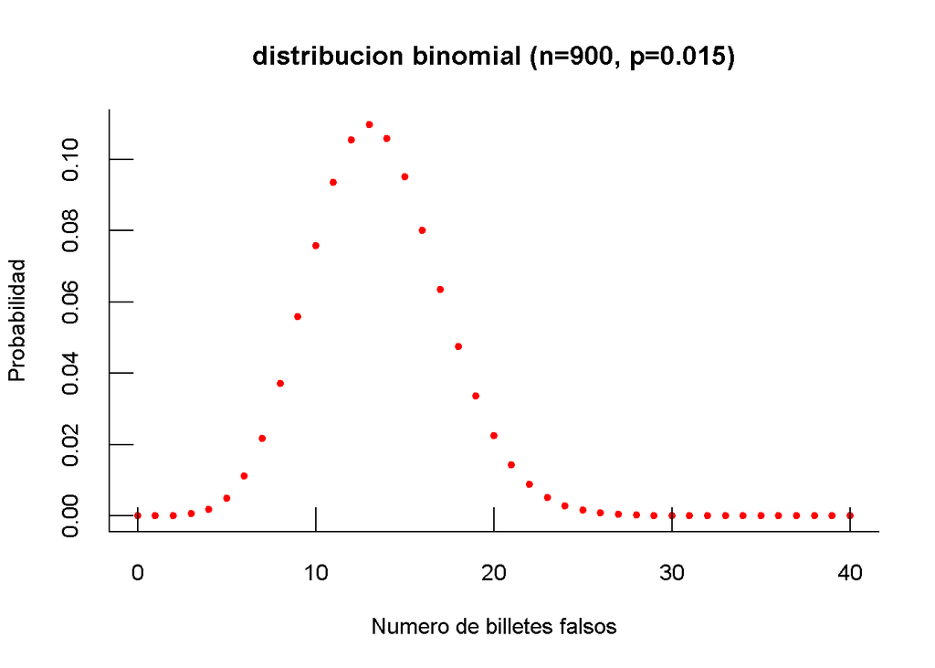

```r
plot(0:40,dbinom(0:40,900,0.015),xlab = " Numero de billetes falsos ",
     ylab = "Probabilidad",main="distribucion binomial (n=900, p=0.015)",
     pch=20, col="red", bty="l", tcl=0.9);
```

*3. Según un estudio del Departamento Nacional de Estadística -DANE-,la vida media para el quinquenio de 2010 a 2015 de los habitantes de Colombia es 76 años, con una varianza de 25. Se pretende hacer un estudio con el objetivo de extrapolar los resultados anteriores a una pequeña ciudad de 100.000 habitantes, considerando que el tiempo de sobrevida es normal.*

*a.¿Cuántos de los habitantes de la pequeña ciudad superarán previsiblemente los 92 años?*

```r
cant = ((1-pnorm(92,76,5))*100)
cat("La cantidad de habitantes que superaran los 92 años es de: ",floor((100000* ((cant))/100 )))
```

```
## La cantidad de habitantes que superaran los 92 años es de:  68
```

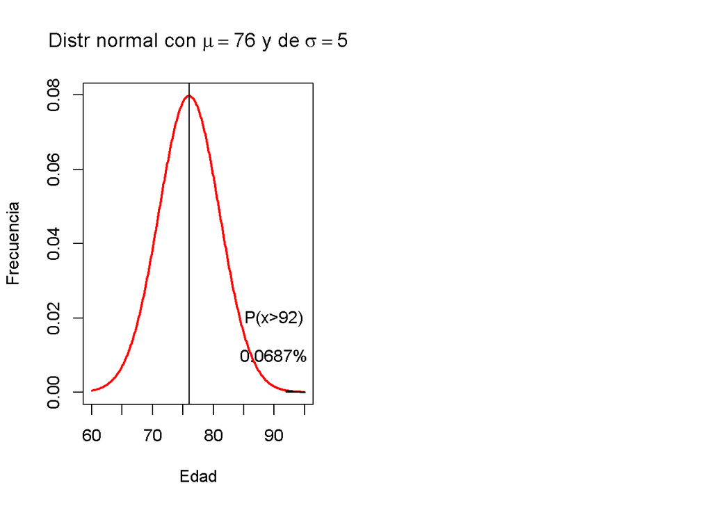

```r
par(mfrow = c(1,2))
x <- seq(60, 95, 0.1)
plot(x, dnorm(x, mean = 76, sd = 5), type = "l",
     ylim = c(0, 0.08), xlab = "Edad", ylab = "Frecuencia",
     main=expression(paste("Distr normal con ",mu==76," y de ", sigma==5)),
     lwd = 2, col = "red")
regionX=seq(92,95,0.01)
xP <- c(92,regionX,95)
yP <- c(0,dnorm(regionX,76,5),0)
polygon(xP,yP)
text(90, 0.02, "P(x>92)")
text(90, 0.01, "0.0687%")
abline(v = 76)
```

*b. ¿Cuántos vivirán menos de 55 años o más de 75 años?*

```r
cat("Los que viviran menos de 55 son un porsentaje de: ",pnorm(55,76,5)*100)
```

```
## Los que viviran menos de 55 son un porsentaje de:  0.001334575
```

```r
cat("\nLos que viviran mas de 75 son un porsentaje de: ",(1-pnorm(75,76,5))*100)
```

```
##
## Los que viviran mas de 75 son un porsentaje de:  57.92597
```

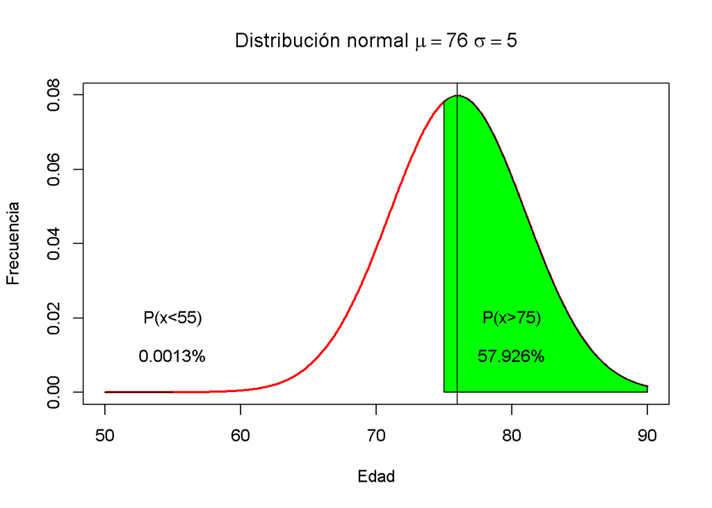

```r
x <- seq(50, 90, 0.1)
plot(x, dnorm(x, mean = 76, sd = 5), type = "l",
     ylim = c(0, 0.08), xlab = "Edad", ylab = "Frecuencia",
     main=expression(paste("Distribución normal ",mu==76," ", sigma==5)),
     lwd = 2, col = "red")
firstReg = seq(50,55,0.01)
xP <- c(50,firstReg,55)
yP <- c(0,dnorm(firstReg,76,5),0)
polygon(xP,yP,col="blue")
secondReg = seq(75,90,0.01)
xP <- c(75,secondReg,90)
yP <- c(0,dnorm(secondReg,76,5),0)
polygon(xP,yP,col="green")
text(55, 0.02, "P(x<55)")
text(55, 0.01, "0.0013%")
text(80, 0.02, "P(x>75)")
text(80, 0.01, "57.926%")
abline(v = 76)
```

```r
cat("\nCon un porsentaje total de: ",((1-pnorm(75,76,5))+pnorm(55,76,5))*100)
```

```
##
## Con un porsentaje total de:  57.92731
```